# Madison Weather - Overview

Jessi Kehe

This R Markdown document was adapted from documents created by Professor Bret Lager.

## Overview of Madison Weather Data

> The source of the data for this week is from the National Oceanic and Atmospheric Administration (NOAA) of the United States.

The data file is `madison-weather-2020.csv`, and the variable descriptions are provided below.

STATION: unique code for the weather station  
NAME: station name  
LATITUDE: station latitude  
LONGITUDE: station longitude  
ELEVATION: station elevation (feet above sea level)  
DATE: date of observations  
AWND: average wind speed (mph)  
PRCP: precipitation (inches, water)  
SNOW: snow fall (inches)  
SNWD: snow depth (inches)  
TAVG: daily average air temperature (degrees Fahrenheit)  
TMAX: maximum air temperature (degrees Fahrenheit)  
TMIN: minimum air temperature (degrees Fahrenheit)  
WSF1: maximum one-minute wind speed

### Import and Transform Data

```r
## Read in the data
## Specify the type
## This is needed to avoid issues for columns where first 1000 rows are all missing
##   and the type is set to logical
mw <- read_csv("madison-weather-2020.csv",
              col_types = cols(
  STATION = col_character(),
  NAME = col_character(),
  LATITUDE = col_double(),
  LONGITUDE = col_double(),
  ELEVATION = col_double(),
  DATE = col_date(format = ""),
  AWND = col_double(),
  PRCP = col_double(),
  SNOW = col_double(),
  SNWD = col_double(),
  TAVG = col_double(),
  TMAX = col_double(),
  TMIN = col_double(),
  WSF1 = col_double()
))


## recode the NAME variable
mw <- mw %>%
  mutate(NAME = recode(NAME,
                       `ARBORETUM UNIVERSITY WIS, WI US` = "Arboretum",
                       `CHARMANY FARM, WI US` = "Charmany",
                       `MADISON DANE CO REGIONAL AIRPORT, WI US` = "Airport",
                       `MADISON MUNICIPAL AIRPORT, WI US` = "Municipal Airport",
                       `MADISON WEATHER BUREAU CITY, WI US` = "Bureau"))

## Select a few columns and reduce to two weather stations
## Rename the variables with lower case letters
mw = mw %>%
  select(NAME,DATE,PRCP,TMAX,TMIN) %>%
  filter(NAME == "Airport" | NAME == "Bureau") %>%
  rename(name = NAME,
         date = DATE,
         prcp = PRCP,
         tmax = TMAX,
         tmin = TMIN)

## Find earliest and latest date
mw %>%
  group_by(name) %>%
  summarize(min = min(date),max=max(date))
```

```
## # A tibble: 2 x 3
##   name    min        max
##   <chr>   <date>     <date>
## 1 Airport 1939-10-01 2020-08-28
## 2 Bureau  1869-01-01 1963-05-31
```

```r
## Decide to use all Airport data
##  and only use Bureau data through 1939-09-30
mw = mw %>%
  filter(name == "Airport" | date < "1939-10-01")

## Double check
mw %>%
  group_by(name) %>%
  summarize(min = min(date),max=max(date))
```

```
## # A tibble: 2 x 3
##   name    min        max
##   <chr>   <date>     <date>
## 1 Airport 1939-10-01 2020-08-28
## 2 Bureau  1869-01-01 1939-09-30
```

```r
## Check missing data
mw %>%
  summarize_all(function(x) sum(is.na(x)))
```

```
## # A tibble: 1 x 5
##    name  date  prcp  tmax  tmin
##   <int> <int> <int> <int> <int>
## 1     0     0    11     4     5
```

```r
## Drop rows with missing data
mw = mw %>%
  drop_na()

## Calculate average temperature and precipitation by year
## Drop partial year of 2020
## Add a period for 30-year periods from 1870 through 2019
breaks = seq(1869,2019,30)
labels = str_c((breaks+1)[-6],breaks[-1],sep="-") #?str_c: Joins two or more vectors element-wise into a single character vector, optionally inserting sep between input vectors.
mw_year = mw %>%
  mutate(tavg = (tmin+tmax)/2) %>%
  mutate(year = year(date)) %>%
  filter(year < 2020 & year > 1869) %>%
  group_by(year) %>%
  summarize(n = n(),
            tmin = mean(tmin),
            tavg = mean(tavg),
            tmax = mean(tmax),
            prcp = sum(prcp)) %>%
  mutate(period = cut(year,
                      breaks = breaks,
                      labels = labels))
## Summarize by month and period
mw_month = mw %>%
  mutate(tavg = (tmin+tmax)/2) %>%
  mutate(month = month(date, label=TRUE)) %>%
  mutate(year = year(date)) %>%
  filter(year < 2020 & year > 1869) %>%
  mutate(period = cut(year,
                      breaks = breaks,
                      labels = labels)) %>%
  group_by(period,month) %>%
  summarize(n=n(),
            tmin = mean(tmin),
            tmax = mean(tmax),
            tavg = mean(tavg),
            prcp = sum(prcp))
```

### Graph of minimum temp over time

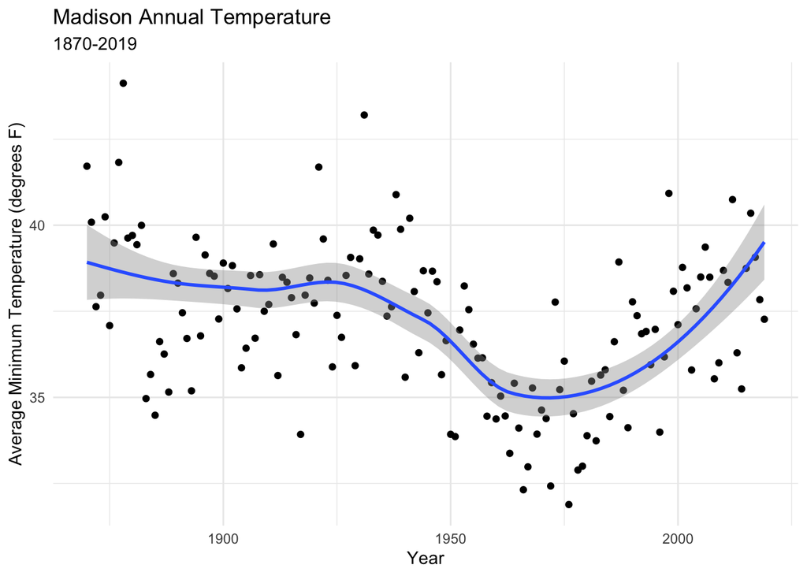

```r
ggplot(mw_year, aes(x=year, y=tmin)) +
  geom_point() +
  geom_smooth() +
  xlab("Year") +
  ylab("Average Minimum Temperature (degrees F)") +
  ggtitle("Madison Annual Temperature",
          subtitle = "1870-2019")
```

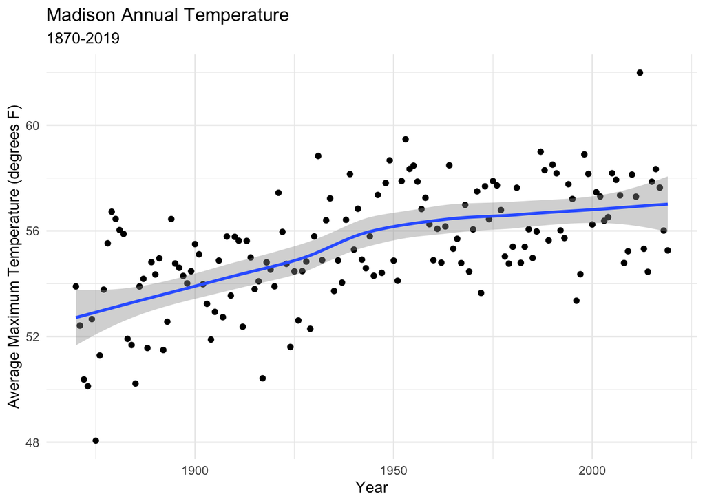

```r
ggplot(mw_year, aes(x=year, y=tmax)) +
  geom_point() +
  geom_smooth() +
  xlab("Year") +
  ylab("Average Maximum Temperature (degrees F)") +
  ggtitle("Madison Annual Temperature",
          subtitle = "1870-2019")
```

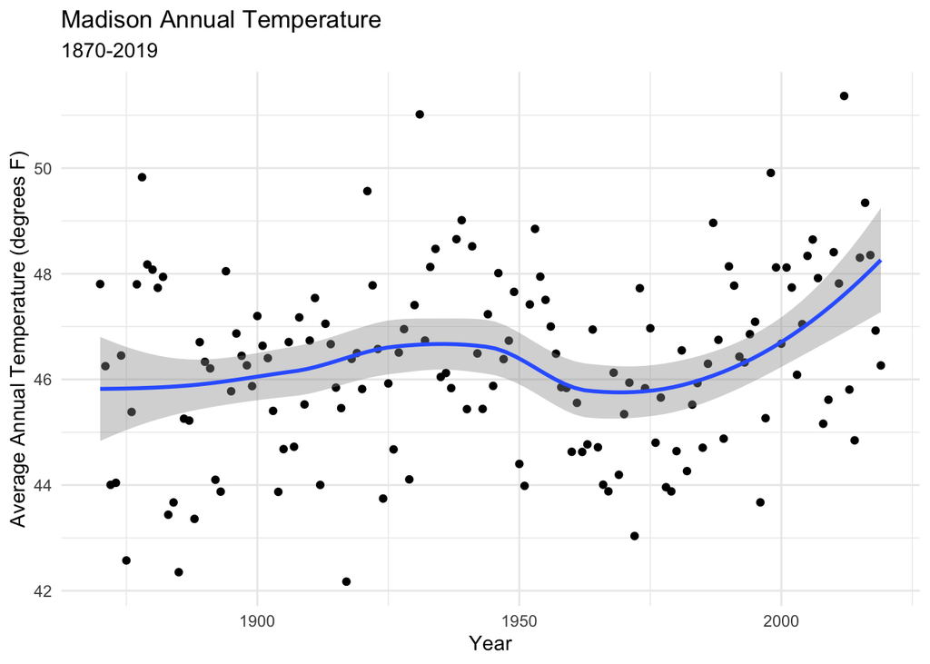

```r
ggplot(mw_year, aes(x=year, y=tavg)) +
  geom_point() +
  geom_smooth() +
  xlab("Year") +
  ylab("Average Annual Temperature (degrees F)") +
  ggtitle("Madison Annual Temperature",
          subtitle = "1870-2019")
```

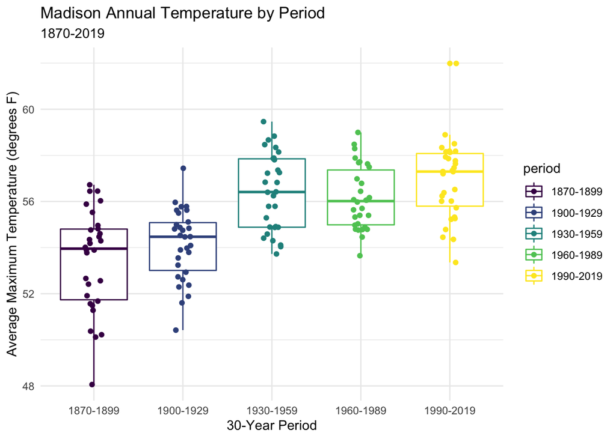

```r
ggplot(mw_year, aes(x=period, y=tmax, color=period)) +
  geom_boxplot() +
  geom_point(position = position_jitter(width=0.1,height=0)) +
  xlab("30-Year Period") +
  ylab("Average Maximum Temperature (degrees F)") +
  ggtitle("Madison Annual Temperature by Period",
          subtitle = "1870-2019")
```

#### Precipitation Plots

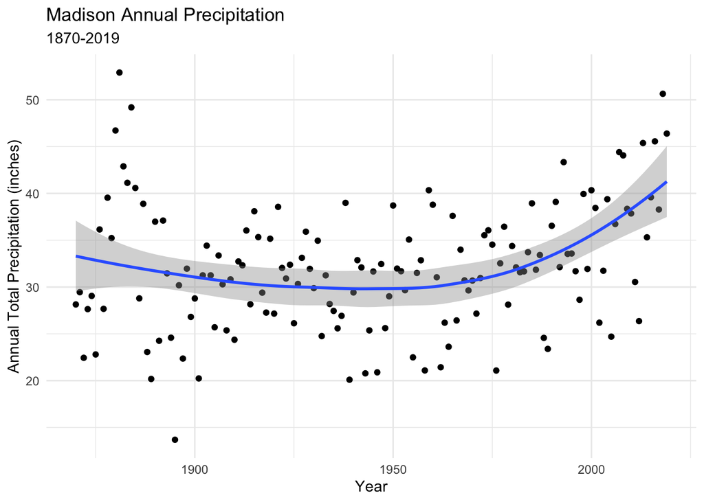

```r
ggplot(mw_year, aes(x=year, y=prcp)) +
  geom_point() +
  geom_smooth() +
  xlab("Year") +
  ylab("Annual Total Precipitation (inches)") +
  ggtitle("Madison Annual Precipitation",
          subtitle = "1870-2019")
```

#### Period Month Plot

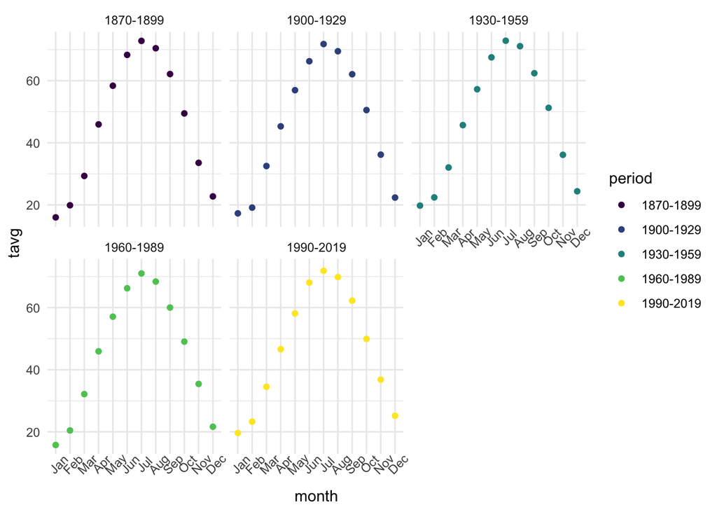

```r
ggplot(mw_month, aes(x=month,y=tavg,color=period)) +
  geom_point() +
  facet_wrap(~period) +
  theme(axis.text.x = element_text(angle=45))
```